# 01 — Validate IBGE input data

This notebook performs a **diagnostic-only validation** of the two GeoParquet inputs used in the Petrópolis OpenStreetMap study:

1. `Petropolis_2025_4674_IBGE.parquet` — municipal boundary;
2. `petropolis_grade_id26_4674_IBGE.parquet` — IBGE 200 m statistical grid.

The notebook does **not** aggregate the grid to 1 km and does not modify source files. It inspects Parquet/GeoParquet metadata, validates CRS and geometries, detects the official IBGE hierarchy fields, checks the uniqueness of the 200 m identifier, counts 200 m cells per official 1 km parent, validates metric dimensions, and produces a PASS/WARNING/FAIL summary for Notebook 02.

All code, variable names, comments, and outputs are in English.

```python
from pathlib import Path
import json
import re
import sys
import platform

import numpy as np
import pandas as pd
import geopandas as gpd
import matplotlib.pyplot as plt
import pyarrow as pa
import pyarrow.parquet as pq

pd.set_option('display.max_columns', 100)
pd.set_option('display.width', 160)
pd.set_option('display.max_colwidth', 120)

print('Python:', sys.version.split()[0])
print('Platform:', platform.platform())
print('GeoPandas:', gpd.__version__)
print('Pandas:', pd.__version__)
print('PyArrow:', pa.__version__)
```

```
Python: 3.12.13
Platform: Linux-6.17.0-1020-azure-x86_64-with-glibc2.39
GeoPandas: 1.1.4
Pandas: 3.0.5
PyArrow: 25.0.1
```

## 1. Locate and validate the input files

```python
def find_project_root(start: Path) -> Path:
    """Find the repository root by locating the Petropolis directory."""
    start = start.resolve()
    for candidate in [start, start.parent, *start.parents]:
        if (candidate / 'Petropolis').exists():
            return candidate
    raise FileNotFoundError("Could not locate the repository root containing 'Petropolis'.")

PROJECT_ROOT = find_project_root(Path.cwd())
DATA_DIR = PROJECT_ROOT / 'Petropolis'
MUNICIPALITY_FILE = DATA_DIR / 'Petropolis_2025_4674_IBGE.parquet'
GRID_FILE = DATA_DIR / 'petropolis_grade_id26_4674_IBGE.parquet'

for path in [MUNICIPALITY_FILE, GRID_FILE]:
    if not path.exists():
        raise FileNotFoundError(f'Required input file not found: {path}')

print('Project root:', PROJECT_ROOT)
print('PASS — Both input files exist.')
```

```
Project root: /home/runner/work/sotm-br-2026/sotm-br-2026
PASS — Both input files exist.
```

## 2. Inspect physical Parquet and GeoParquet metadata

```python
def inspect_parquet_metadata(path: Path) -> dict:
    """Return Parquet schema and decoded GeoParquet metadata."""
    pf = pq.ParquetFile(path)
    raw = pf.metadata.metadata or {}
    decoded = {}
    for key, value in raw.items():
        k = key.decode('utf-8', errors='replace')
        try:
            text = value.decode('utf-8')
            decoded[k] = json.loads(text) if k == 'geo' else text
        except Exception:
            decoded[k] = '<binary or non-UTF8 metadata>'
    return {
        'rows': pf.metadata.num_rows,
        'row_groups': pf.metadata.num_row_groups,
        'columns': pf.metadata.num_columns,
        'schema': pf.schema_arrow,
        'metadata': decoded,
    }

municipality_meta = inspect_parquet_metadata(MUNICIPALITY_FILE)
grid_meta = inspect_parquet_metadata(GRID_FILE)

for label, meta in [('Municipality', municipality_meta), ('IBGE grid', grid_meta)]:
    print(f'\n--- {label} ---')
    print('Rows:', f"{meta['rows']:,}")
    print('Row groups:', meta['row_groups'])
    print('Columns:', meta['columns'])
    print(meta['schema'])
    print('Geo metadata:')
    print(json.dumps(meta['metadata'].get('geo'), indent=2, ensure_ascii=False))
```

```
--- Municipality ---
Rows: 1
Row groups: 1
Columns: 20
CD_MUN: string
NM_MUN: string
CD_RGI: string
NM_RGI: string
CD_RGINT: string
NM_RGINT: string
CD_UF: string
NM_UF: string
SIGLA_UF: string
CD_REGIAO: string
NM_REGIAO: string
SIGLA_RG: string
CD_CONCURB: string
NM_CONCURB: string
AREA_KM2: decimal128(12, 3)
geometry: binary
geometry_bbox: struct<xmin: float not null, ymin: float not null, xmax: float not null, ymax: float not null>
  child 0, xmin: float not null
  child 1, ymin: float not null
  child 2, xmax: float not null
  child 3, ymax: float not null
-- schema metadata --
gdal:schema: '{"columns":{"CD_MUN":{"type":"String","width":7},"NM_MUN":{' + 554
geo: '{"version":"1.1.0","primary_column":"geometry","columns":{"geometry' + 1176
Geo metadata:
{
  "version": "1.1.0",
  "primary_column": "geometry",
  "columns": {
    "geometry": {
      "encoding": "WKB",
      "crs": {
        "$schema": "https://proj.org/schemas/v0.7/projjson.schema.json",
        "type": "GeographicCRS",
        "name": "SIRGAS 2000",
        "datum": {
```

[output cut: 163 more lines]

```
            "xmax"
          ],
          "ymax": [
            "geometry_bbox",
            "ymax"
          ]
        }
      },
      "orientation": "counterclockwise",
      "geometry_types": [
        "MultiPolygon"
      ]
    }
  }
}
```

## 3. Load datasets and inspect exact schemas

```python
municipality = gpd.read_parquet(MUNICIPALITY_FILE)
grid_200m = gpd.read_parquet(GRID_FILE)

def schema_table(gdf: gpd.GeoDataFrame) -> pd.DataFrame:
    return pd.DataFrame({
        'column': gdf.columns,
        'dtype': [str(dtype) for dtype in gdf.dtypes],
        'non_null': [int(gdf[col].notna().sum()) for col in gdf.columns],
        'null': [int(gdf[col].isna().sum()) for col in gdf.columns],
    })

print(f'Municipality features: {len(municipality):,}')
display(schema_table(municipality))
print(f'IBGE grid features: {len(grid_200m):,}')
display(schema_table(grid_200m))
display(grid_200m.head())
```

```
Municipality features: 1
```

|  | column | dtype | non_null | null |
| --- | --- | --- | --- | --- |
| 0 | CD_MUN | str | 1 | 0 |
| 1 | NM_MUN | str | 1 | 0 |
| 2 | CD_RGI | str | 1 | 0 |
| 3 | NM_RGI | str | 1 | 0 |
| 4 | CD_RGINT | str | 1 | 0 |
| 5 | NM_RGINT | str | 1 | 0 |
| 6 | CD_UF | str | 1 | 0 |
| 7 | NM_UF | str | 1 | 0 |
| 8 | SIGLA_UF | str | 1 | 0 |
| 9 | CD_REGIAO | str | 1 | 0 |
| 10 | NM_REGIAO | str | 1 | 0 |
| 11 | SIGLA_RG | str | 1 | 0 |
| 12 | CD_CONCURB | str | 1 | 0 |
| 13 | NM_CONCURB | str | 1 | 0 |
| 14 | AREA_KM2 | object | 1 | 0 |
| 15 | geometry | geometry | 1 | 0 |

```
IBGE grid features: 25,055
```

|  | column | dtype | non_null | null |
| --- | --- | --- | --- | --- |
| 0 | ID_UNICO | str | 25055 | 0 |
| 1 | nome_1km | str | 25055 | 0 |
| 2 | nome_5KM | str | 25055 | 0 |
| 3 | nome_10KM | str | 25055 | 0 |
| 4 | nome_50KM | str | 25055 | 0 |
| 5 | nome_100KM | str | 25055 | 0 |
| 6 | nome_500KM | str | 25055 | 0 |
| 7 | QUADRANTE | str | 25055 | 0 |
| 8 | TOTAL | int64 | 25055 | 0 |
| 9 | TOTAL_DOM | int64 | 25055 | 0 |
| 10 | geometry | geometry | 25055 | 0 |

|  | ID_UNICO | nome_1km | nome_5KM | nome_10KM | nome_50KM | nome_100KM | nome_500KM | QUADRANTE | TOTAL | TOTAL_DOM | geometry |
| --- | --- | --- | --- | --- | --- | --- | --- | --- | --- | --- | --- |
| 0 | 200ME61170N87960 | 1KME6117N8795 | 5KME6115N8795 | 10KME6110N8790 | 50KME6100N8750 | 100KME6100N8750 | 500KME5800N8350 | ID_26 | 0 | 0 | MULTIPOLYGON (((-43.156 -22.58185, -43.15406 -22.58178, -43.15413 -22.57997, -43.15607 -22.58004, -43.156 -22.58185))) |
| 1 | 200ME61172N87960 | 1KME6117N8795 | 5KME6115N8795 | 10KME6110N8790 | 50KME6100N8750 | 100KME6100N8750 | 500KME5800N8350 | ID_26 | 0 | 0 | MULTIPOLYGON (((-43.15406 -22.58178, -43.15212 -22.58171, -43.15219 -22.5799, -43.15413 -22.57997, -43.15406 -22.581... |
| 2 | 200ME61174N87960 | 1KME6117N8795 | 5KME6115N8795 | 10KME6110N8790 | 50KME6100N8750 | 100KME6100N8750 | 500KME5800N8350 | ID_26 | 0 | 0 | MULTIPOLYGON (((-43.15212 -22.58171, -43.15018 -22.58164, -43.15025 -22.57983, -43.15219 -22.5799, -43.15212 -22.581... |
| 3 | 200ME61176N87960 | 1KME6117N8795 | 5KME6115N8795 | 10KME6110N8790 | 50KME6100N8750 | 100KME6100N8750 | 500KME5800N8350 | ID_26 | 0 | 0 | MULTIPOLYGON (((-43.15018 -22.58164, -43.14824 -22.58157, -43.14832 -22.57976, -43.15025 -22.57983, -43.15018 -22.58... |
| 4 | 200ME61178N87960 | 1KME6117N8795 | 5KME6115N8795 | 10KME6110N8790 | 50KME6100N8750 | 100KME6100N8750 | 500KME5800N8350 | ID_26 | 0 | 0 | MULTIPOLYGON (((-43.14824 -22.58157, -43.1463 -22.5815, -43.14638 -22.57969, -43.14832 -22.57976, -43.14824 -22.5815... |

## 4. CRS validation

Both datasets are expected to use **SIRGAS 2000 / EPSG:4674**. Metric measurements are performed later in SIRGAS 2000 / UTM zone 23S (EPSG:31983).

```python
def epsg_or_none(gdf):
    return None if gdf.crs is None else gdf.crs.to_epsg()

municipality_epsg = epsg_or_none(municipality)
grid_epsg = epsg_or_none(grid_200m)

print('Municipality CRS:', municipality.crs)
print('Municipality EPSG:', municipality_epsg)
print('Grid CRS:', grid_200m.crs)
print('Grid EPSG:', grid_epsg)

display(pd.Series({
    'municipality_has_crs': municipality.crs is not None,
    'grid_has_crs': grid_200m.crs is not None,
    'same_crs': municipality.crs == grid_200m.crs,
    'municipality_epsg_4674': municipality_epsg == 4674,
    'grid_epsg_4674': grid_epsg == 4674,
}, name='result'))
```

```
Municipality CRS: {"$schema": "https://proj.org/schemas/v0.7/projjson.schema.json", "type": "GeographicCRS", "name": "SIRGAS 2000", "datum": {"type": "GeodeticReferenceFrame", "name": "Sistema de Referencia Geocentrico para las AmericaS 2000", "ellipsoid": {"name": "GRS 1980", "semi_major_axis": 637…
Municipality EPSG: 4674
Grid CRS: {"$schema": "https://proj.org/schemas/v0.7/projjson.schema.json", "type": "GeographicCRS", "name": "SIRGAS 2000", "datum": {"type": "GeodeticReferenceFrame", "name": "Sistema de Referencia Geocentrico para las AmericaS 2000", "ellipsoid": {"name": "GRS 1980", "semi_major_axis": 6378137, "i…
Grid EPSG: 4674
```

```
municipality_has_crs      True
grid_has_crs              True
same_crs                  True
municipality_epsg_4674    True
grid_epsg_4674            True
Name: result, dtype: bool
```

## 5. Geometry diagnostics

```python
def geometry_diagnostics(gdf, label):
    geom = gdf.geometry
    non_empty = geom[geom.notna() & ~geom.is_empty]
    return {
        'dataset': label,
        'features': len(gdf),
        'geometry_column': gdf.geometry.name,
        'geometry_types': geom.geom_type.value_counts(dropna=False).to_dict(),
        'null_geometries': int(geom.isna().sum()),
        'empty_geometries': int(geom.is_empty.sum()),
        'invalid_geometries': int((~non_empty.is_valid).sum()),
        'duplicate_geometries': int(geom.duplicated().sum()),
        'bounds': tuple(gdf.total_bounds.tolist()),
    }

municipality_geom_diag = geometry_diagnostics(municipality, 'Municipality')
grid_geom_diag = geometry_diagnostics(grid_200m, 'IBGE 200 m grid')
display(pd.DataFrame([municipality_geom_diag, grid_geom_diag]))
```

|  | dataset | features | geometry_column | geometry_types | null_geometries | empty_geometries | invalid_geometries | duplicate_geometries | bounds |
| --- | --- | --- | --- | --- | --- | --- | --- | --- | --- |
| 0 | Municipality | 1 | geometry | {'MultiPolygon': 1} | 0 | 0 | 0 | 0 | (-43.3773012999999, -22.5733326, -42.9779814, -22.2025201) |
| 1 | IBGE 200 m grid | 25055 | geometry | {'MultiPolygon': 25055} | 0 | 0 | 0 | 0 | (-43.4218158459807, -22.598093060276664, -42.92898210594485, -22.18110274652542) |

## 6. Detect the official IBGE hierarchy fields

The aggregation in Notebook 02 will use the official `nome_1km` hierarchy rather than a newly generated geometric index.

```python
def find_column_case_insensitive(columns, candidates):
    lookup = {str(col).lower(): col for col in columns}
    for candidate in candidates:
        if candidate.lower() in lookup:
            return lookup[candidate.lower()]
    return None

ID_200M_COL = find_column_case_insensitive(grid_200m.columns, ['ID_UNICO', 'id_unico'])
PARENT_1KM_COL = find_column_case_insensitive(grid_200m.columns, ['nome_1km'])

hierarchy_patterns = {
    '200m_unique_id': ['ID_UNICO'],
    '1km_parent': ['nome_1km'],
    '5km_parent': ['nome_5km'],
    '10km_parent': ['nome_10km'],
    '50km_parent': ['nome_50km'],
    '100km_parent': ['nome_100km'],
    '500km_parent': ['nome_500km'],
    'quadrant': ['quadrante'],
}
detected_hierarchy = {role: find_column_case_insensitive(grid_200m.columns, names) for role, names in hierarchy_patterns.items()}
display(pd.DataFrame(detected_hierarchy.items(), columns=['hierarchy_role', 'detected_column']))

if ID_200M_COL is None:
    raise KeyError('Could not detect the IBGE 200 m unique-cell identifier field.')
if PARENT_1KM_COL is None:
    raise KeyError('Could not detect the IBGE 1 km parent-cell identifier field.')
```

|  | hierarchy_role | detected_column |
| --- | --- | --- |
| 0 | 200m_unique_id | ID_UNICO |
| 1 | 1km_parent | nome_1km |
| 2 | 5km_parent | nome_5KM |
| 3 | 10km_parent | nome_10KM |
| 4 | 50km_parent | nome_50KM |
| 5 | 100km_parent | nome_100KM |
| 6 | 500km_parent | nome_500KM |
| 7 | quadrant | QUADRANTE |

## 7. Validate 200 m identifiers and 1 km parent identifiers

```python
id_series = grid_200m[ID_200M_COL]
parent_series = grid_200m[PARENT_1KM_COL]

display(pd.Series({
    '200m_id_non_null': bool(id_series.notna().all()),
    '200m_id_unique': bool(id_series.is_unique),
    '200m_duplicate_count': int(id_series.duplicated().sum()),
    '200m_unique_count': int(id_series.nunique(dropna=True)),
    '1km_parent_null_count': int(parent_series.isna().sum()),
    '1km_parent_unique_count': int(parent_series.nunique(dropna=True)),
}, name='value'))

print('Sample 200 m identifiers:')
display(id_series.dropna().astype(str).head(20).to_frame())
print('Sample 1 km parent identifiers:')
display(parent_series.dropna().astype(str).drop_duplicates().head(20).to_frame())

pattern_200m = re.compile(r'^200M[Ee]?\d+[Nn]?\d+$')
pattern_matches = id_series.dropna().astype(str).str.match(pattern_200m)
print('IDs matching expected textual pattern:', f'{pattern_matches.sum():,} / {len(pattern_matches):,}')
```

```
200m_id_non_null            True
200m_id_unique              True
200m_duplicate_count           0
200m_unique_count          25055
1km_parent_null_count          0
1km_parent_unique_count     2192
Name: value, dtype: object
```

```
Sample 200 m identifiers:
```

|  | ID_UNICO |
| --- | --- |
| 0 | 200ME61170N87960 |
| 1 | 200ME61172N87960 |
| 2 | 200ME61174N87960 |
| 3 | 200ME61176N87960 |
| 4 | 200ME61178N87960 |
| 5 | 200ME61180N87960 |
| 6 | 200ME61182N87960 |
| 7 | 200ME61184N87960 |
| 8 | 200ME61186N87960 |
| 9 | 200ME61188N87960 |
| 10 | 200ME61190N87960 |
| 11 | 200ME61192N87960 |
| 12 | 200ME61194N87960 |
| 13 | 200ME61196N87960 |
| 14 | 200ME61198N87960 |
| 15 | 200ME61210N87960 |
| 16 | 200ME61212N87960 |
| 17 | 200ME61214N87960 |
| 18 | 200ME61216N87960 |
| 19 | 200ME61218N87960 |

```
Sample 1 km parent identifiers:
```

|  | nome_1km |
| --- | --- |
| 0 | 1KME6117N8795 |
| 5 | 1KME6118N8795 |
| 10 | 1KME6119N8795 |
| 15 | 1KME6121N8795 |
| 20 | 1KME6117N8796 |
| 25 | 1KME6118N8796 |
| 30 | 1KME6130N8796 |
| 95 | 1KME6105N8797 |
| 100 | 1KME6112N8797 |
| 105 | 1KME6115N8797 |
| 110 | 1KME6131N8797 |
| 195 | 1KME6104N8798 |
| 200 | 1KME6105N8798 |
| 245 | 1KME6105N8799 |
| 270 | 1KME6133N8805 |
| 295 | 1KME6095N8811 |
| 320 | 1KME6093N8812 |
| 345 | 1KME6125N8813 |
| 350 | 1KME6126N8813 |
| 355 | 1KME6127N8813 |

```
IDs matching expected textual pattern: 23,864 / 25,055
```

## 8. Count 200 m source cells per official 1 km parent

A complete 1 km × 1 km cell should contain **25** cells of 200 m × 200 m.

```python
cells_per_1km = (
    grid_200m.groupby(PARENT_1KM_COL, dropna=False)
    .size()
    .rename('n_200m_cells')
    .reset_index()
)
cells_per_1km['is_complete_25'] = cells_per_1km['n_200m_cells'].eq(25)

print(f'Unique 1 km parent groups: {len(cells_per_1km):,}')
print(f"Complete 25-cell groups: {cells_per_1km['is_complete_25'].sum():,}")
print(f"Groups with count != 25: {(~cells_per_1km['is_complete_25']).sum():,}")
display(
    cells_per_1km['n_200m_cells'].value_counts().sort_index()
    .rename_axis('n_200m_cells')
    .reset_index(name='number_of_1km_parent_groups')
)
display(cells_per_1km[cells_per_1km['n_200m_cells'].ne(25)].sort_values('n_200m_cells'))
```

```
Unique 1 km parent groups: 2,192
Complete 25-cell groups: 920
Groups with count != 25: 1,272
```

|  | n_200m_cells | number_of_1km_parent_groups |
| --- | --- | --- |
| 0 | 1 | 1192 |
| 1 | 5 | 24 |
| 2 | 6 | 1 |
| 3 | 8 | 1 |
| 4 | 9 | 1 |
| 5 | 10 | 23 |
| 6 | 12 | 1 |
| 7 | 13 | 2 |
| 8 | 15 | 17 |
| 9 | 16 | 1 |
| 10 | 20 | 8 |
| 11 | 21 | 1 |
| 12 | 25 | 920 |

|  | nome_1km | n_200m_cells | is_complete_25 |
| --- | --- | --- | --- |
| 1114 | 1KME6115N8834 | 1 | False |
| 1143 | 1KME6116N8818 | 1 | False |
| 1123 | 1KME6116N8798 | 1 | False |
| 1122 | 1KME6116N8797 | 1 | False |
| 2113 | 1KME6138N8829 | 1 | False |
| ... | ... | ... | ... |
| 2135 | 1KME6139N8808 | 20 | False |
| 2136 | 1KME6139N8809 | 20 | False |
| 2137 | 1KME6139N8810 | 20 | False |
| 2036 | 1KME6136N8838 | 20 | False |
| 2138 | 1KME6139N8811 | 21 | False |

1272 rows × 3 columns

## 9. Validate nominal cell size in a metric CRS

EPSG:4674 is geographic. Metric diagnostics therefore use **SIRGAS 2000 / UTM zone 23S (EPSG:31983)**. A nominal 200 m cell should have an area close to 40,000 m².

```python
METRIC_CRS = 'EPSG:31983'
grid_metric = grid_200m.to_crs(METRIC_CRS)
municipality_metric = municipality.to_crs(METRIC_CRS)

area_m2 = grid_metric.geometry.area
bounds = grid_metric.geometry.bounds
width_m = bounds['maxx'] - bounds['minx']
height_m = bounds['maxy'] - bounds['miny']

print('200 m cell area statistics (m²):')
display(area_m2.describe(percentiles=[0.01, 0.05, 0.50, 0.95, 0.99]).to_frame('area_m2'))
print('Approximate bounding-box dimensions (m):')
display(pd.DataFrame({
    'width_m': width_m.describe(percentiles=[0.01, 0.05, 0.50, 0.95, 0.99]),
    'height_m': height_m.describe(percentiles=[0.01, 0.05, 0.50, 0.95, 0.99]),
}))

EXPECTED_200M_AREA_M2 = 40_000.0
AREA_TOLERANCE = 0.02
within_expected_area = area_m2.between(
    EXPECTED_200M_AREA_M2 * (1 - AREA_TOLERANCE),
    EXPECTED_200M_AREA_M2 * (1 + AREA_TOLERANCE),
)
print('Cells within ±2% of 40,000 m²:', f'{within_expected_area.sum():,} / {len(grid_metric):,}')
```

```
200 m cell area statistics (m²):
```

|  | area_m2 |
| --- | --- |
| count | 2.505500e+04 |
| mean | 8.564049e+04 |
| std | 2.042823e+05 |
| min | 3.999441e+04 |
| 1% | 3.999469e+04 |
| 5% | 3.999569e+04 |
| 50% | 4.000496e+04 |
| 95% | 4.001244e+04 |
| 99% | 1.000198e+06 |
| max | 1.000321e+06 |

```
Approximate bounding-box dimensions (m):
```

|  | width_m | height_m |
| --- | --- | --- |
| count | 25055.000000 | 25055.000000 |
| mean | 243.926307 | 244.588262 |
| std | 174.524496 | 174.922296 |
| min | 204.718805 | 205.296198 |
| 1% | 204.746008 | 205.326893 |
| 5% | 204.783304 | 205.372473 |
| 50% | 204.928846 | 205.512475 |
| 95% | 205.234197 | 205.733480 |
| 99% | 1025.592188 | 1028.016798 |
| max | 1026.262708 | 1028.769523 |

```
Cells within ±2% of 40,000 m²: 23,864 / 25,055
```

## 10. Validate geometric coherence of complete 1 km parent groups

This dissolve is performed **in memory only** for quality control. No file is written.

```python
validation_1km = (
    grid_metric[[PARENT_1KM_COL, grid_metric.geometry.name]]
    .dissolve(by=PARENT_1KM_COL, as_index=False)
)
validation_1km['area_m2'] = validation_1km.geometry.area
validation_1km = validation_1km.merge(
    cells_per_1km[[PARENT_1KM_COL, 'n_200m_cells', 'is_complete_25']],
    on=PARENT_1KM_COL, how='left'
)
complete_1km = validation_1km[validation_1km['is_complete_25']].copy()
complete_1km['area_within_tolerance'] = complete_1km['area_m2'].between(980_000, 1_020_000)

display(complete_1km['area_m2'].describe(percentiles=[0.01, 0.05, 0.50, 0.95, 0.99]).to_frame('area_m2'))
print('Complete parent groups near 1 km²:', f"{complete_1km['area_within_tolerance'].sum():,} / {len(complete_1km):,}")
```

|  | area_m2 |
| --- | --- |
| count | 9.200000e+02 |
| mean | 1.000117e+06 |
| std | 1.112265e+02 |
| min | 9.998671e+05 |
| 1% | 9.998706e+05 |
| 5% | 9.998971e+05 |
| 50% | 1.000118e+06 |
| 95% | 1.000289e+06 |
| 99% | 1.000304e+06 |
| max | 1.000306e+06 |

```
Complete parent groups near 1 km²: 920 / 920
```

## 11. Diagnose the spatial relationship with Petrópolis

```python
municipality_union = municipality_metric.geometry.union_all()
within = grid_metric.geometry.within(municipality_union)
intersects = grid_metric.geometry.intersects(municipality_union)
relation = np.select(
    [within, intersects],
    ['within', 'boundary_intersection'],
    default='outside',
)
display(
    pd.Series(relation, name='spatial_relation')
    .value_counts()
    .rename_axis('spatial_relation')
    .reset_index(name='n_200m_cells')
)
```

|  | spatial_relation | n_200m_cells |
| --- | --- | --- |
| 0 | within | 12402 |
| 1 | outside | 11938 |
| 2 | boundary_intersection | 715 |

## 12. Quick diagnostic maps

These figures are for quality control only, not for publication.

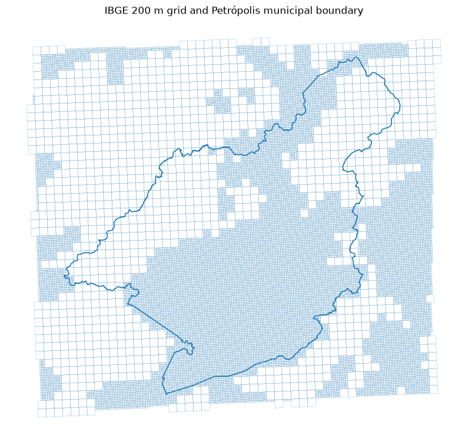

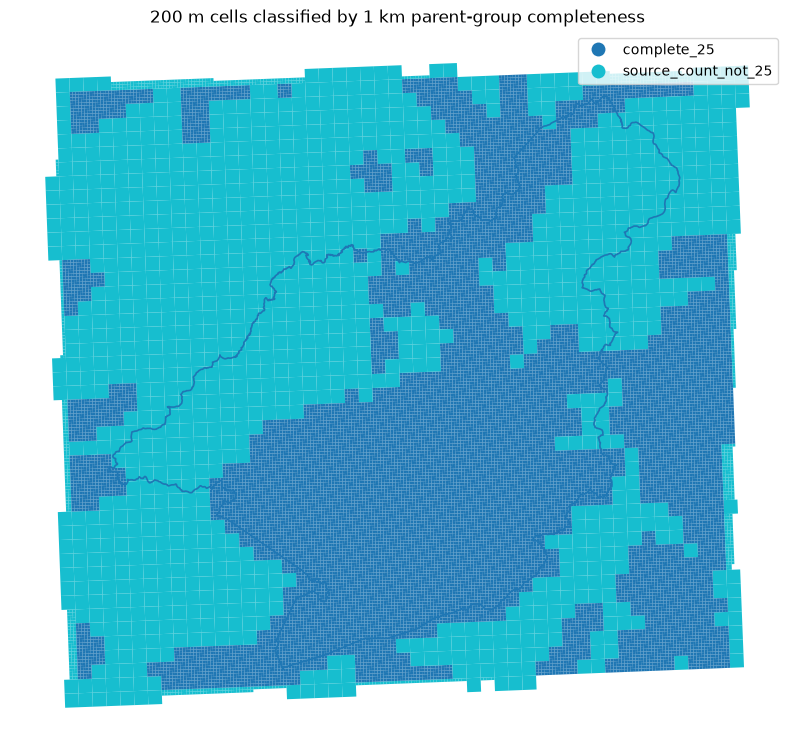

```python
fig, ax = plt.subplots(figsize=(10, 10))
grid_200m.boundary.plot(ax=ax, linewidth=0.15)
municipality.boundary.plot(ax=ax, linewidth=1.2)
ax.set_title('IBGE 200 m grid and Petrópolis municipal boundary')
ax.set_axis_off()
plt.show()

incomplete_ids = set(cells_per_1km.loc[cells_per_1km['n_200m_cells'].ne(25), PARENT_1KM_COL].dropna())
grid_status = grid_200m[[PARENT_1KM_COL, grid_200m.geometry.name]].copy()
grid_status['parent_status'] = np.where(
    grid_status[PARENT_1KM_COL].isin(incomplete_ids),
    'source_count_not_25', 'complete_25'
)
fig, ax = plt.subplots(figsize=(10, 10))
grid_status.plot(column='parent_status', categorical=True, legend=True, ax=ax, linewidth=0)
municipality.boundary.plot(ax=ax, linewidth=1.2)
ax.set_title('200 m cells classified by 1 km parent-group completeness')
ax.set_axis_off()
plt.show()
```

## 13. PASS / WARNING / FAIL summary

```python
def status(condition, warning=False):
    if condition:
        return 'PASS'
    return 'WARNING' if warning else 'FAIL'

share_nominal_200m = float(within_expected_area.mean()) if len(within_expected_area) else 0.0
share_nominal_1km = float(complete_1km['area_within_tolerance'].mean()) if len(complete_1km) else 0.0

diagnostics = [
    ['Municipality CRS is defined', status(municipality.crs is not None), str(municipality.crs)],
    ['Grid CRS is defined', status(grid_200m.crs is not None), str(grid_200m.crs)],
    ['Both datasets use the same CRS', status(municipality.crs == grid_200m.crs), str(municipality.crs == grid_200m.crs)],
    ['Municipality resolves to EPSG:4674', status(municipality_epsg == 4674), str(municipality_epsg)],
    ['Grid resolves to EPSG:4674', status(grid_epsg == 4674), str(grid_epsg)],
    ['200 m identifier is unique', status(id_series.is_unique), f'{id_series.nunique(dropna=True):,} unique IDs'],
    ['No null 200 m identifiers', status(id_series.notna().all()), f'{id_series.isna().sum():,} null IDs'],
    ['No null 1 km parent identifiers', status(parent_series.notna().all()), f'{parent_series.isna().sum():,} null parent IDs'],
    ['No 1 km parent contains more than 25 source cells', status(cells_per_1km['n_200m_cells'].max() <= 25), f"maximum = {cells_per_1km['n_200m_cells'].max()}"],
    ['All grid geometries are valid', status(grid_geom_diag['invalid_geometries'] == 0), f"{grid_geom_diag['invalid_geometries']:,} invalid"],
    ['All grid geometries are non-empty', status(grid_geom_diag['empty_geometries'] == 0), f"{grid_geom_diag['empty_geometries']:,} empty"],
    ['200 m cells are approximately 40,000 m²', status(share_nominal_200m >= 0.99, share_nominal_200m >= 0.90), f'{share_nominal_200m:.2%} within ±2%'],
    ['Complete 25-cell parents are approximately 1 km²', status(share_nominal_1km >= 0.99, share_nominal_1km >= 0.90), f'{share_nominal_1km:.2%} within ±2%'],
]
diagnostic_table = pd.DataFrame(diagnostics, columns=['check', 'status', 'value'])
display(diagnostic_table)
display(diagnostic_table['status'].value_counts().reindex(['PASS', 'WARNING', 'FAIL'], fill_value=0).to_frame('count'))
```

|  | check | status | value |
| --- | --- | --- | --- |
| 0 | Municipality CRS is defined | PASS | {"$schema": "https://proj.org/schemas/v0.7/projjson.schema.json", "type": "GeographicCRS", "name": "SIRGAS 2000", "d... |
| 1 | Grid CRS is defined | PASS | {"$schema": "https://proj.org/schemas/v0.7/projjson.schema.json", "type": "GeographicCRS", "name": "SIRGAS 2000", "d... |
| 2 | Both datasets use the same CRS | PASS | True |
| 3 | Municipality resolves to EPSG:4674 | PASS | 4674 |
| 4 | Grid resolves to EPSG:4674 | PASS | 4674 |
| 5 | 200 m identifier is unique | PASS | 25,055 unique IDs |
| 6 | No null 200 m identifiers | PASS | 0 null IDs |
| 7 | No null 1 km parent identifiers | PASS | 0 null parent IDs |
| 8 | No 1 km parent contains more than 25 source cells | PASS | maximum = 25 |
| 9 | All grid geometries are valid | PASS | 0 invalid |
| 10 | All grid geometries are non-empty | PASS | 0 empty |
| 11 | 200 m cells are approximately 40,000 m² | WARNING | 95.25% within ±2% |
| 12 | Complete 25-cell parents are approximately 1 km² | PASS | 100.00% within ±2% |

| status | count |
| --- | --- |
| PASS | 12 |
| WARNING | 1 |
| FAIL | 0 |

## 14. Decision rule for Notebook 02

Proceed to the 200 m → 1 km aggregation only after confirming the diagnostic summary. The intended aggregation method is based on the **official IBGE 1 km parent identifier**:

```
grid_1km = grid_200m.dissolve(
    by=PARENT_1KM_COL,
    as_index=False,
)
```

Notebook 02 should preserve the official 1 km identifier, the number of 200 m source cells, a source-group completeness flag, the original 1 km geometry, and the fraction of each 1 km cell intersecting Petrópolis.

No source file is modified by this notebook.